# Using data.table

## What Is It?

The most simple descriptor is that data.table extends base R’s functionality and makes it faster. It also borrows from dplyr’s notion of piping operations. A departure from typical base R is that data.table includes an extra position in the brackets.

We’ve already seen fread, so let’s continue to use it:

```r
library(data.table)

nba_data <- fread("https://www.nd.edu/~sberry5/data/nba_data.csv")

str(nba_data)
```

```
Classes 'data.table' and 'data.frame':  26039 obs. of  33 variables:
 $ V1               : int  0 1 2 3 4 5 6 7 8 9 ...
 $ SEASON_ID        : int  22021 22021 22021 22021 22021 22021 22021 22021 22021 22021 ...
 $ PLAYER_ID        : int  1627774 202328 1628396 1629669 1629750 1630172 1630195 1630233 1630245 1630792 ...
 $ PLAYER_NAME      : chr  "Jake Layman" "Greg Monroe" "Tony Bradley" "Jaylen Nowell" ...
 $ TEAM_ID          : int  1610612750 1610612750 1610612741 1610612750 1610612741 1610612741 1610612750 1610612750 1610612741 1610612741 ...
 $ TEAM_ABBREVIATION: chr  "MIN" "MIN" "CHI" "MIN" ...
 $ TEAM_NAME        : chr  "Minnesota Timberwolves" "Minnesota Timberwolves" "Chicago Bulls" "Minnesota Timberwolves" ...
 $ GAME_ID          : int  22101224 22101224 22101224 22101224 22101224 22101224 22101224 22101224 22101224 22101224 ...
 $ GAME_DATE        : IDate, format: "2022-04-10" "2022-04-10" ...
 $ MATCHUP          : chr  "MIN vs. CHI" "MIN vs. CHI" "CHI @ MIN" "MIN vs. CHI" ...
 $ WL               : chr  "L" "L" "W" "L" ...
 $ MIN              : int  17 18 15 21 40 41 18 16 45 13 ...
 $ FGM              : int  3 4 5 6 4 10 4 7 9 1 ...
 $ FGA              : int  3 8 8 12 8 21 9 12 18 2 ...
```

[output cut: 20 more lines]

## Selection

Very similar to base R, but with a very convenient difference!

```r
nba_data[, list(PTS, TEAM_ID, GAME_ID)]
```

```
       PTS    TEAM_ID  GAME_ID
    1:  10 1610612750 22101224
    2:   9 1610612750 22101224
    3:  11 1610612741 22101224
    4:  15 1610612750 22101224
    5:   8 1610612741 22101224
   ---
26035:  34 1610612747 22100002
26036:   6 1610612747 22100002
26037:  15 1610612744 22100002
26038:  15 1610612744 22100002
26039:  12 1610612744 22100002
```

```r
nba_data[, list(PTS, pt_calc = PTS*1.5, TEAM_ID, GAME_ID)]
```

```
       PTS pt_calc    TEAM_ID  GAME_ID
    1:  10    15.0 1610612750 22101224
    2:   9    13.5 1610612750 22101224
    3:  11    16.5 1610612741 22101224
    4:  15    22.5 1610612750 22101224
    5:   8    12.0 1610612741 22101224
   ---
26035:  34    51.0 1610612747 22100002
26036:   6     9.0 1610612747 22100002
26037:  15    22.5 1610612744 22100002
26038:  15    22.5 1610612744 22100002
26039:  12    18.0 1610612744 22100002
```

## Filtering

Again, very base like.

```r
nba_data[PTS > 10, ]
```

```
          V1 SEASON_ID PLAYER_ID      PLAYER_NAME    TEAM_ID TEAM_ABBREVIATION
    1:     2     22021   1628396     Tony Bradley 1610612741               CHI
    2:     3     22021   1629669    Jaylen Nowell 1610612750               MIN
    3:     5     22021   1630172 Patrick Williams 1610612741               CHI
    4:     6     22021   1630195  Leandro Bolmaro 1610612750               MIN
    5:     7     22021   1630233    Nathan Knight 1610612750               MIN
   ---
10969: 26031     22021    203076    Anthony Davis 1610612747               LAL
10970: 26034     22021      2544     LeBron James 1610612747               LAL
10971: 26036     22021   1627814       Damion Lee 1610612744               GSW
10972: 26037     22021    202357  Nemanja Bjelica 1610612744               GSW
10973: 26038     22021    203952   Andrew Wiggins 1610612744               GSW
                    TEAM_NAME  GAME_ID  GAME_DATE     MATCHUP WL MIN FGM FGA
    1:          Chicago Bulls 22101224 2022-04-10   CHI @ MIN  W  15   5   8
    2: Minnesota Timberwolves 22101224 2022-04-10 MIN vs. CHI  L  21   6  12
```

[output cut: 33 more lines]

```r
nba_data[PTS > 10]
```

```
          V1 SEASON_ID PLAYER_ID      PLAYER_NAME    TEAM_ID TEAM_ABBREVIATION
    1:     2     22021   1628396     Tony Bradley 1610612741               CHI
    2:     3     22021   1629669    Jaylen Nowell 1610612750               MIN
    3:     5     22021   1630172 Patrick Williams 1610612741               CHI
    4:     6     22021   1630195  Leandro Bolmaro 1610612750               MIN
    5:     7     22021   1630233    Nathan Knight 1610612750               MIN
   ---
10969: 26031     22021    203076    Anthony Davis 1610612747               LAL
10970: 26034     22021      2544     LeBron James 1610612747               LAL
10971: 26036     22021   1627814       Damion Lee 1610612744               GSW
10972: 26037     22021    202357  Nemanja Bjelica 1610612744               GSW
10973: 26038     22021    203952   Andrew Wiggins 1610612744               GSW
                    TEAM_NAME  GAME_ID  GAME_DATE     MATCHUP WL MIN FGM FGA
    1:          Chicago Bulls 22101224 2022-04-10   CHI @ MIN  W  15   5   8
    2: Minnesota Timberwolves 22101224 2022-04-10 MIN vs. CHI  L  21   6  12
```

[output cut: 33 more lines]

## Grouping

The group_by and summarize from dplyr can be handled with one line:

```r
nba_data[, list(avg_pts = mean(PTS)), by = list(TEAM_ID, GAME_ID)]
```

```
         TEAM_ID  GAME_ID   avg_pts
   1: 1610612750 22101224  8.571429
   2: 1610612741 22101224 13.777778
   3: 1610612755 22101228 13.111111
   4: 1610612765 22101228  9.636364
   5: 1610612738 22101223  9.928571
  ---
2456: 1610612754 22100003 15.250000
2457: 1610612749 22100001 10.583333
2458: 1610612751 22100001  8.000000
2459: 1610612744 22100002 10.083333
2460: 1610612747 22100002 11.400000
```

## Special Symbols

Now we get to the crazy! Powerful, but crazy.

```r
nba_data[, .N]
```

```
[1] 26039
```

```r
nba_data[, .N, by = PLAYER_NAME]
```

```
            PLAYER_NAME  N
  1:        Jake Layman 34
  2:        Greg Monroe 14
  3:       Tony Bradley 55
  4:      Jaylen Nowell 62
  5:      Javonte Green 65
 ---
601:    Sekou Doumbouya  2
602:      Collin Sexton 11
603: Michael Porter Jr.  9
604:      DeJon Jarreau  1
605:         Sam Dekker  1
```

```r
nba_data[, grp := .GRP, by = list(PLAYER_NAME)]
```

```r
setkey(nba_data, PLAYER_NAME)
```

```r
nba_data[, player_game_number := sequence(.N), by = key(nba_data)]
```

```r
nba_data[, .SD, .SDcols = FGM:FT_PCT]
```

```
       FGM FGA FG_PCT FG3M FG3A FG3_PCT FTM FTA FT_PCT
    1:   7  11  0.636    3    5   0.600   5   5   1.00
    2:   8  16  0.500    0    3   0.000   2   4   0.50
    3:   9  14  0.643    3    5   0.600   3   4   0.75
    4:   9  11  0.818    4    6   0.667   2   2   1.00
    5:   4   7  0.571    2    4   0.500   0   0     NA
   ---
26035:   1   3  0.333    1    3   0.333   2   2   1.00
26036:   1   6  0.167    1    4   0.250   0   0     NA
26037:   2   4  0.500    2    4   0.500   0   0     NA
26038:   1   2  0.500    1    1   1.000   0   0     NA
26039:   0   3  0.000    0    2   0.000   0   0     NA
```

```r
nba_data[, .SD, .SDcols = c("PLAYER_NAME", "FGM")]
```

```
           PLAYER_NAME FGM
    1:    Aaron Gordon   7
    2:    Aaron Gordon   8
    3:    Aaron Gordon   9
    4:    Aaron Gordon   9
    5:    Aaron Gordon   4
   ---
26035: Ziaire Williams   1
26036: Ziaire Williams   1
26037: Ziaire Williams   2
26038: Ziaire Williams   1
26039:  Zylan Cheatham   0
```

```r
nba_data[, .SD, .SDcols = patterns("PCT")]
```

```
       FG_PCT FG3_PCT FT_PCT
    1:  0.636   0.600   1.00
    2:  0.500   0.000   0.50
    3:  0.643   0.600   0.75
    4:  0.818   0.667   1.00
    5:  0.571   0.500     NA
   ---
26035:  0.333   0.333   1.00
26036:  0.167   0.250     NA
26037:  0.500   0.500     NA
26038:  0.500   1.000     NA
26039:  0.000   0.000     NA
```

```r
fg_vars <- c("FG_PCT", "FG3_PCT", "FT_PCT")

nba_data[, fg_vars] <- nba_data[,  lapply(.SD, function(x) x * 100), .SDcols = fg_vars]

nba_data[, ..fg_vars]
```

```
       FG_PCT FG3_PCT FT_PCT
    1:   63.6    60.0    100
    2:   50.0     0.0     50
    3:   64.3    60.0     75
    4:   81.8    66.7    100
    5:   57.1    50.0     NA
   ---
26035:   33.3    33.3    100
26036:   16.7    25.0     NA
26037:   50.0    50.0     NA
26038:   50.0   100.0     NA
26039:    0.0     0.0     NA
```

## Chaining Indices

```r
top_pt_performance <-
  nba_data[,
           list(player_game_number = sequence(.N), PTS),
           by = key(nba_data)
  ][
    order(PTS),
    .SD[.N],
    by = PLAYER_NAME
  ][PTS > 40]
```

## Reshaping

The same functions from reshape2 – melt and dcast – are offered in data.table.

Let’s subset down to just players and teams:

```r
team_avg <- nba_data[,
                     list(sum_fg = sum(FGM),
                          sum_3pt = sum(FG3M)),
                     by = list(TEAM_ABBREVIATION, GAME_ID)
][,
  list(mean_fg = mean(sum_fg),
       mean_3pt = mean(sum_3pt)),
  by = list(TEAM_ABBREVIATION)]
```

```r
melted_avg <- melt.data.table(team_avg,
                              id.vars = "TEAM_ABBREVIATION",
                              variable.name = "stat",
                              value.name = "value")
```

## Merging

What comes below might not be immediately clear, but stick with me for a minute:

```r
library(glue)
library(httr)
library(jsonlite)

all_players <- purrr::map_df(0:52, ~{
  Sys.sleep(runif(1, 0, 1))

  base_link <- glue("https://www.balldontlie.io/api/v1/players?page={.x}&per_page=100")

  request <- GET(base_link)

  json_data <- fromJSON(content(request, as = "text"))

  player_data <- json_data$data

  player_data
})

all_players$full_name <- paste(all_players$first_name,
                               all_players$last_name,
                               sep = " ")

all_players <- all_players[,
                           c("full_name", "height_feet",
                             "height_inches", "weight_pounds")]

all_players <- as.data.table(all_players)
```

Now that we have that data, we can perform a join!

```r
sum(top_pt_performance$PLAYER_NAME %in% all_players$full_name)
```

```
[1] 38
```

```r
top_performance <- all_players[top_pt_performance, on = "full_name==PLAYER_NAME"]
```

```r
top_performance[,
            total_height := height_feet * 12 + height_inches
]
```

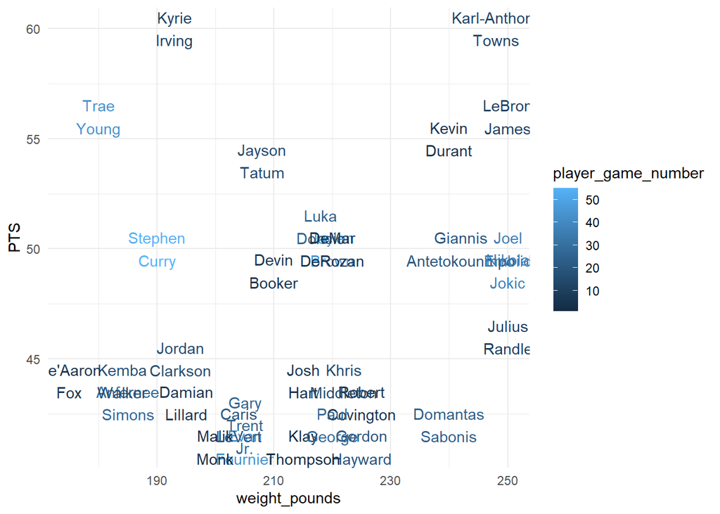

```r
library(ggplot2)

top_performance$plot_name <- gsub("\\s", "\n", top_performance$full_name)

ggplot(top_performance, aes(weight_pounds, PTS, color = player_game_number,
                        label = plot_name)) +
  geom_text() +
  theme_minimal()
```

## Why Care?

1. You want to be one of the few people who can read and write the 3 major R dialects.
2. What are the goals. If you need something rapid, the tidyverse is great. However, it doesn’t always play nicely in the broader R ecosystem. The beauty of base R is that it doesn’t really change, but it is slow.
3. Speed

Let’s see how some basic operations work.

```r
library(microbenchmark)
library(dplyr)
library(tibble)

nba_df <- as.data.frame(nba_data)

nba_tibble <- as_tibble(nba_data)

microbenchmark({nba_df[nba_df$PTS > 15, ]},
               {filter(nba_tibble, PTS > 15)},
               {nba_data[PTS > 15]})
```

```
Unit: milliseconds
                                 expr    min      lq     mean  median      uq
    {     nba_df[nba_df$PTS > 15, ] } 2.6775 3.69770 4.353062 3.76160 3.89925
 {     filter(nba_tibble, PTS > 15) } 1.5527 2.21095 2.687426 2.34245 2.45015
           {     nba_data[PTS > 15] } 1.6577 2.00945 2.849841 2.69410 3.09555
     max neval
  8.8549   100
 10.2109   100
  8.3127   100
```

Now with something a little trickier:

```r
base_order <- function() {
  nba_df[nba_df$PTS > 15, c("PTS", "PLAYER_NAME")] |>
    (\(x) x[order(x$PTS), ])()
}

dplyr_order <- function() {
  nba_tibble %>%
    filter(PTS > 15) %>%
    select(PTS, PLAYER_NAME) %>%
    arrange(PTS)
}

dt_order <- function() {
  nba_data[PTS > 15, list(PTS, PLAYER_NAME)][order(PTS)]
}

microbenchmark(base_order(),
               dplyr_order(),
               dt_order())
```

```
Unit: microseconds
          expr    min      lq     mean  median      uq     max neval
  base_order()  817.1  959.55 1114.296  981.55 1013.25  5908.5   100
 dplyr_order() 5014.5 5448.10 6221.542 5774.35 6126.55 13761.4   100
    dt_order() 1456.5 1719.85 1957.503 1809.70 1973.10  7766.2   100
```

This only becomes more pronounced as we get more complicated data. While base R can sometime be fast, it will fall apart when operations get bigger. Not only that, but data.table has the fastest joins of all:

```r
players_df <- as.data.frame(all_players)

players_tibble <- as_tibble(all_players)

base_merge <- function() {
  merge(nba_df, players_df,
        by.x = "PLAYER_NAME", by.y = "full_name")
}

dplyr_merge <- function() {
  left_join(nba_tibble, players_tibble, c("PLAYER_NAME" = "full_name"))
}

dt_merge <- function() {
  merge(nba_data, all_players,
        by.x = "PLAYER_NAME", by.y = "full_name")
}

microbenchmark(base_merge(),
               dplyr_merge(),
               dt_merge())
```

[output not shown]

[output cut: 49 more lines]

[output not shown]

```
Unit: milliseconds
          expr     min       lq     mean   median      uq      max neval
  base_merge() 77.2347 81.52460 88.19743 83.34885 86.1922 154.4087   100
 dplyr_merge() 18.2217 19.02895 21.75713 20.68660 23.1288  72.9838   100
    dt_merge()  7.7475  9.73675 11.91845 10.98025 14.0097  24.5527   100
```

Again, we can see a clear advantage emerge!